# Week 14 IP Part 1 - Carrefour Kenya

```r
# update all available packages
update.packages()
```

[output not shown]

[output not shown]

[output not shown]

[output not shown]

[output not shown]

```r
install.packages("data.table")
install.packages("tidyverse")
install.packages("lubridate")
install.packages('cutr')
install.packages('modeest')
install.packages('moments')
install.packages('janitor')
install.packages('ggcorrplot')
install.packages('caret')
install.packages('arules')
install.packages("anomalize")
install.packages('tibbletime')
install.packages('timetk')
install.packages("arulesViz")
install.packages("dplyr")
install.packages("tibble")
install.packages("tibbletime")
install.packages('dummies')
install.packages('devtools')
install.packages("grid")
install.packages("reshape2")
install.packages("plyr")
install.packages("scales")
install.packages("ggplot2")
```

```r
install.packages("openxlsx")
```

[output not shown]

```r
library(openxlsx)
library(reshape2)
library(plyr)
library(scales)
library(ggplot2)
library(devtools)
library(grid)
library(corrplot)
```

```r
library("data.table")
library("tidyverse")
library('lubridate')
library("modeest")
library("moments")
library("janitor")
library(ggcorrplot)
library('caret')
library('arules')
library('anomalize')
library('tibbletime')
library('timetk')
library('arulesViz')
require('dplyr')
library('dummies')
library('devtools')
library(dplyr)
####################################### Works
```

##2. Reading and checking of data

```r
#Load the readr library to bring in the dataset
library(readr)
#Reading and checking the sales data
Sales <- read.csv('http://bit.ly/CarreFourDataset')
head(Sales)
```

|  | Invoice.ID | Branch | Customer.type | Gender | Product.line | Unit.price | Quantity | Tax | Date | Time | Payment | cogs | gross.margin.percentage | gross.income | Rating | Total |
| --- | --- | --- | --- | --- | --- | --- | --- | --- | --- | --- | --- | --- | --- | --- | --- | --- |
| 1 | 750-67-8428 | A | Member | Female | Health and beauty | 74.69 | 7 | 26.1415 | 1/5/2019 | 13:08 | Ewallet | 522.83 | 4.761905 | 26.1415 | 9.1 | 548.9715 |
| 2 | 226-31-3081 | C | Normal | Female | Electronic accessories | 15.28 | 5 | 3.8200 | 3/8/2019 | 10:29 | Cash | 76.40 | 4.761905 | 3.8200 | 9.6 | 80.2200 |
| 3 | 631-41-3108 | A | Normal | Male | Home and lifestyle | 46.33 | 7 | 16.2155 | 3/3/2019 | 13:23 | Credit card | 324.31 | 4.761905 | 16.2155 | 7.4 | 340.5255 |
| 4 | 123-19-1176 | A | Member | Male | Health and beauty | 58.22 | 8 | 23.2880 | 1/27/2019 | 20:33 | Ewallet | 465.76 | 4.761905 | 23.2880 | 8.4 | 489.0480 |
| 5 | 373-73-7910 | A | Normal | Male | Sports and travel | 86.31 | 7 | 30.2085 | 2/8/2019 | 10:37 | Ewallet | 604.17 | 4.761905 | 30.2085 | 5.3 | 634.3785 |
| 6 | 699-14-3026 | C | Normal | Male | Electronic accessories | 85.39 | 7 | 29.8865 | 3/25/2019 | 18:30 | Ewallet | 597.73 | 4.761905 | 29.8865 | 4.1 | 627.6165 |

```r
#Checking the dimensions of the table
dim(Sales)
```

```
[1] 1000   16
```

```r
#Displaying the type and a preview of all columns
#
glimpse(Sales)
```

```
Rows: 1,000
Columns: 16
$ Invoice.ID              <chr> "750-67-8428", "226-31-3081", "631-41-3108", "123-19-1176", "373-73-7910", "699-14-3026", "355-53-5943", "315-22-5665", "665-32-9167", "692-92~
$ Branch                  <chr> "A", "C", "A", "A", "A", "C", "A", "C", "A", "B", "B", "B", "A", "A", "A", "B", "A", "A", "A", "B", "C", "B", "B", "A", "A", "A", "B", "A", "B~
$ Customer.type           <chr> "Member", "Normal", "Normal", "Member", "Normal", "Normal", "Member", "Normal", "Member", "Member", "Member", "Member", "Normal", "Normal", "N~
$ Gender                  <chr> "Female", "Female", "Male", "Male", "Male", "Male", "Female", "Female", "Female", "Female", "Female", "Male", "Female", "Male", "Female", "Fem~
$ Product.line            <chr> "Health and beauty", "Electronic accessories", "Home and lifestyle", "Health and beauty", "Sports and travel", "Electronic accessories", "Elec~
$ Unit.price              <dbl> 74.69, 15.28, 46.33, 58.22, 86.31, 85.39, 68.84, 73.56, 36.26, 54.84, 14.48, 25.51, 46.95, 43.19, 71.38, 93.72, 68.93, 72.61, 54.67, 40.30, 86~
$ Quantity                <int> 7, 5, 7, 8, 7, 7, 6, 10, 2, 3, 4, 4, 5, 10, 10, 6, 7, 6, 3, 2, 5, 3, 2, 5, 3, 8, 1, 2, 5, 9, 5, 9, 8, 2, 4, 1, 5, 9, 8, 8, 1, 2, 6, 8, 2, 4, 9~
$ Tax                     <dbl> 26.1415, 3.8200, 16.2155, 23.2880, 30.2085, 29.8865, 20.6520, 36.7800, 3.6260, 8.2260, 2.8960, 5.1020, 11.7375, 21.5950, 35.6900, 28.1160, 24.~
$ Date                    <chr> "1/5/2019", "3/8/2019", "3/3/2019", "1/27/2019", "2/8/2019", "3/25/2019", "2/25/2019", "2/24/2019", "1/10/2019", "2/20/2019", "2/6/2019", "3/9~
$ Time                    <chr> "13:08", "10:29", "13:23", "20:33", "10:37", "18:30", "14:36", "11:38", "17:15", "13:27", "18:07", "17:03", "10:25", "16:48", "19:21", "16:19"~
$ Payment                 <chr> "Ewallet", "Cash", "Credit card", "Ewallet", "Ewallet", "Ewallet", "Ewallet", "Ewallet", "Credit card", "Credit card", "Ewallet", "Cash", "Ewa~
$ cogs                    <dbl> 522.83, 76.40, 324.31, 465.76, 604.17, 597.73, 413.04, 735.60, 72.52, 164.52, 57.92, 102.04, 234.75, 431.90, 713.80, 562.32, 482.51, 435.66, 1~
$ gross.margin.percentage <dbl> 4.761905, 4.761905, 4.761905, 4.761905, 4.761905, 4.761905, 4.761905, 4.761905, 4.761905, 4.761905, 4.761905, 4.761905, 4.761905, 4.761905, 4.~
$ gross.income            <dbl> 26.1415, 3.8200, 16.2155, 23.2880, 30.2085, 29.8865, 20.6520, 36.7800, 3.6260, 8.2260, 2.8960, 5.1020, 11.7375, 21.5950, 35.6900, 28.1160, 24.~
$ Rating                  <dbl> 9.1, 9.6, 7.4, 8.4, 5.3, 4.1, 5.8, 8.0, 7.2, 5.9, 4.5, 6.8, 7.1, 8.2, 5.7, 4.5, 4.6, 6.9, 8.6, 4.4, 4.8, 5.1, 4.4, 9.9, 6.0, 8.5, 6.7, 7.7, 9.~
$ Total                   <dbl> 548.9715, 80.2200, 340.5255, 489.0480, 634.3785, 627.6165, 433.6920, 772.3800, 76.1460, 172.7460, 60.8160, 107.1420, 246.4875, 453.4950, 749.4~
```

```r
#Checking on summary statistics of numeric variables
summary(Sales)
```

```
  Invoice.ID           Branch          Customer.type         Gender          Product.line         Unit.price       Quantity          Tax              Date
 Length:1000        Length:1000        Length:1000        Length:1000        Length:1000        Min.   :10.08   Min.   : 1.00   Min.   : 0.5085   Length:1000
 Class :character   Class :character   Class :character   Class :character   Class :character   1st Qu.:32.88   1st Qu.: 3.00   1st Qu.: 5.9249   Class :character
 Mode  :character   Mode  :character   Mode  :character   Mode  :character   Mode  :character   Median :55.23   Median : 5.00   Median :12.0880   Mode  :character
                                                                                                Mean   :55.67   Mean   : 5.51   Mean   :15.3794
                                                                                                3rd Qu.:77.94   3rd Qu.: 8.00   3rd Qu.:22.4453
                                                                                                Max.   :99.96   Max.   :10.00   Max.   :49.6500
     Time             Payment               cogs        gross.margin.percentage  gross.income         Rating           Total
 Length:1000        Length:1000        Min.   : 10.17   Min.   :4.762           Min.   : 0.5085   Min.   : 4.000   Min.   :  10.68
 Class :character   Class :character   1st Qu.:118.50   1st Qu.:4.762           1st Qu.: 5.9249   1st Qu.: 5.500   1st Qu.: 124.42
 Mode  :character   Mode  :character   Median :241.76   Median :4.762           Median :12.0880   Median : 7.000   Median : 253.85
                                       Mean   :307.59   Mean   :4.762           Mean   :15.3794   Mean   : 6.973   Mean   : 322.97
                                       3rd Qu.:448.90   3rd Qu.:4.762           3rd Qu.:22.4453   3rd Qu.: 8.500   3rd Qu.: 471.35
                                       Max.   :993.00   Max.   :4.762           Max.   :49.6500   Max.   :10.000   Max.   :1042.65
```

##3. Data Cleaning

```r
## To ensure uniformity, I will lowercase all the columns
names(Sales)<- tolower(names(Sales))
head(Sales)
```

|  | invoice.id | branch | customer.type | gender | product.line | unit.price | quantity | tax | date | time | payment | cogs | gross.margin.percentage | gross.income | rating | total |
| --- | --- | --- | --- | --- | --- | --- | --- | --- | --- | --- | --- | --- | --- | --- | --- | --- |
| 1 | 750-67-8428 | A | Member | Female | Health and beauty | 74.69 | 7 | 26.1415 | 1/5/2019 | 13:08 | Ewallet | 522.83 | 4.761905 | 26.1415 | 9.1 | 548.9715 |
| 2 | 226-31-3081 | C | Normal | Female | Electronic accessories | 15.28 | 5 | 3.8200 | 3/8/2019 | 10:29 | Cash | 76.40 | 4.761905 | 3.8200 | 9.6 | 80.2200 |
| 3 | 631-41-3108 | A | Normal | Male | Home and lifestyle | 46.33 | 7 | 16.2155 | 3/3/2019 | 13:23 | Credit card | 324.31 | 4.761905 | 16.2155 | 7.4 | 340.5255 |
| 4 | 123-19-1176 | A | Member | Male | Health and beauty | 58.22 | 8 | 23.2880 | 1/27/2019 | 20:33 | Ewallet | 465.76 | 4.761905 | 23.2880 | 8.4 | 489.0480 |
| 5 | 373-73-7910 | A | Normal | Male | Sports and travel | 86.31 | 7 | 30.2085 | 2/8/2019 | 10:37 | Ewallet | 604.17 | 4.761905 | 30.2085 | 5.3 | 634.3785 |
| 6 | 699-14-3026 | C | Normal | Male | Electronic accessories | 85.39 | 7 | 29.8865 | 3/25/2019 | 18:30 | Ewallet | 597.73 | 4.761905 | 29.8865 | 4.1 | 627.6165 |

Next I’m going to checking for missing values in our dataset,,Missing values may affect the perfomance of our model, so we will find a way to deal with them

```r
#Checking for missing values in the columns of our dataset
#
colSums(is.na(Sales))
```

```
             invoice.id                  branch           customer.type                  gender            product.line              unit.price                quantity
                      0                       0                       0                       0                       0                       0                       0
                    tax                    date                    time                 payment                    cogs gross.margin.percentage            gross.income
                      0                       0                       0                       0                       0                       0                       0
                 rating                   total
                      0                       0
```

There is no missing data in any column Lets now check for duplicates in our dataset

```r
anyDuplicated(Sales)
```

```
[1] 0
```

We dont have duplicates in our dataset Lets now check for outliers in our dataset

```r
## obtaining numerical columns
numeric_columns <- unlist(lapply(Sales, is.numeric))
```

```r
## I will put the numerical columns in a dataframe
columns_numeric <- Sales[ , numeric_columns]
head(columns_numeric)
```

|  | unit.price | quantity | tax | cogs | gross.margin.percentage | gross.income | rating | total |
| --- | --- | --- | --- | --- | --- | --- | --- | --- |
| 1 | 74.69 | 7 | 26.1415 | 522.83 | 4.761905 | 26.1415 | 9.1 | 548.9715 |
| 2 | 15.28 | 5 | 3.8200 | 76.40 | 4.761905 | 3.8200 | 9.6 | 80.2200 |
| 3 | 46.33 | 7 | 16.2155 | 324.31 | 4.761905 | 16.2155 | 7.4 | 340.5255 |
| 4 | 58.22 | 8 | 23.2880 | 465.76 | 4.761905 | 23.2880 | 8.4 | 489.0480 |
| 5 | 86.31 | 7 | 30.2085 | 604.17 | 4.761905 | 30.2085 | 5.3 | 634.3785 |
| 6 | 85.39 | 7 | 29.8865 | 597.73 | 4.761905 | 29.8865 | 4.1 | 627.6165 |

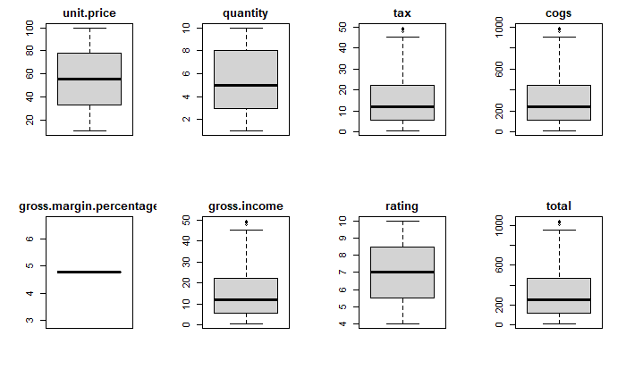

```r
# using a for lop, I will output boxplots of numerical columns..This will help me to identify the outliers
par ( mfrow= c (  2, 4 ))
for (i in 1 : length (columns_numeric)) {
boxplot (columns_numeric[,i], main= names (columns_numeric[i]), type= "l" , height = 200, width = 110)}
```

There are outliers in  
* tax, * gross.income,  
* cogs,  
* Total.

Removing outliers may cause innacurate results from our models. We can also expect outliers in tax and gross income due to the earning capacities of different individuals. This could be an accurate description of reality and therefore we will not be dropping any outliers.

```r
dim(Sales)
```

[output not shown]

```r
dim(Sales)
```

```
[1] 1000   16
```

##Univariate analysis ###Numerical columns Univariate analysis will help us gain insights on the general characteristics of the individual variables in the dataset.

```r
# compute the measures of cenral tendancy and the measures of dispersion of the numerical variables and contain them in a data1frame
stats <- data.frame(
  Mean = apply(columns_numeric, 2, mean),
  Median = apply(columns_numeric, 2, median),
  Min = apply(columns_numeric, 2, min),
  Max = apply(columns_numeric, 2, max),
  Variance= apply(columns_numeric, 2, var),
  Std = apply(columns_numeric, 2, sd),
  Skewness = apply(columns_numeric, 2, skewness),
  Kurtosis = apply(columns_numeric, 2, kurtosis))
# round off the values to 2 decimal places and display the data1frame
stats <- round(stats, 2)
stats
```

|  | Mean | Median | Min | Max | Variance | Std | Skewness | Kurtosis |
| --- | --- | --- | --- | --- | --- | --- | --- | --- |
| unit.price | 55.67 | 55.23 | 10.08 | 99.96 | 701.97 | 26.49 | 0.01 | 1.78 |
| quantity | 5.51 | 5.00 | 1.00 | 10.00 | 8.55 | 2.92 | 0.01 | 1.78 |
| tax | 15.38 | 12.09 | 0.51 | 49.65 | 137.10 | 11.71 | 0.89 | 2.91 |
| cogs | 307.59 | 241.76 | 10.17 | 993.00 | 54838.64 | 234.18 | 0.89 | 2.91 |
| gross.margin.percentage | 4.76 | 4.76 | 4.76 | 4.76 | 0.00 | 0.00 | NaN | NaN |
| gross.income | 15.38 | 12.09 | 0.51 | 49.65 | 137.10 | 11.71 | 0.89 | 2.91 |
| rating | 6.97 | 7.00 | 4.00 | 10.00 | 2.95 | 1.72 | 0.01 | 1.85 |
| total | 322.97 | 253.85 | 10.68 | 1042.65 | 60459.60 | 245.89 | 0.89 | 2.91 |

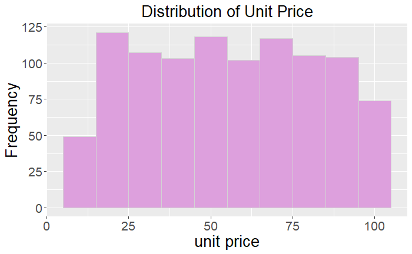

```r
# plot a histogram to visualize the distribution of values in 'unit_price' column
options(repr.plot.width = 8, repr.plot.height = 6)
p = Sales %>% ggplot(aes(x = unit.price ))
p + geom_histogram(color="lightgray", fill="plum", binwidth = 10) +
    labs(title = "Distribution of Unit Price", x = "unit price", y = "Frequency") +
    theme(axis.title = element_text(size = 20),
          axis.text = element_text(size=16),
          plot.title = element_text(hjust = 0.5, size = 20))
```

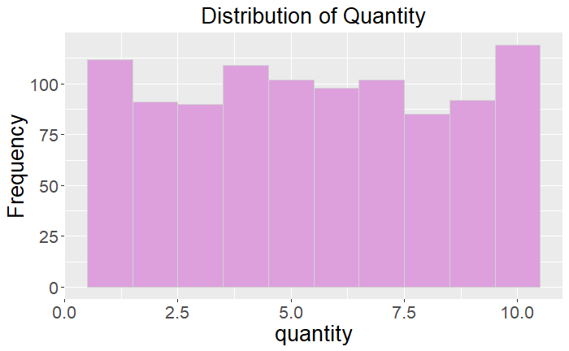

```r
# plot a histogram to visualize the distribution of values in 'quantity' column
options(repr.plot.width = 8, repr.plot.height = 6)
p = Sales %>% ggplot(aes(x = quantity ))
p + geom_histogram(color="lightgray", fill="plum", binwidth = 1) +
    labs(title = "Distribution of Quantity", x = "quantity", y = "Frequency") +
    theme(axis.title = element_text(size = 20),
          axis.text = element_text(size=16),
          plot.title = element_text(hjust = 0.5, size = 20))
```

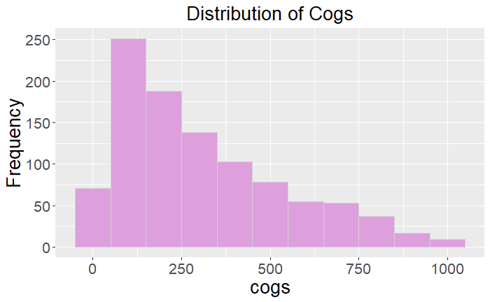

```r
# plot a histogram to visualize the distribution of values in 'cogs' column
options(repr.plot.width = 8, repr.plot.height = 6)
p = Sales %>% ggplot(aes(x = cogs ))
p + geom_histogram(color="lightgray", fill="plum", binwidth = 100) +
    labs(title = "Distribution of Cogs", x = "cogs", y = "Frequency") +
      theme(axis.title = element_text(size = 20),
          axis.text = element_text(size=16),
          plot.title = element_text(hjust = 0.5, size = 20))
```

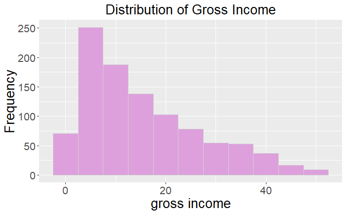

```r
# plot a histogram to visualize the distribution of values in 'gross_income' column
options(repr.plot.width = 8, repr.plot.height = 6)
p = Sales %>% ggplot(aes(x = gross.income ))
p + geom_histogram(color="lightgray", fill="plum", binwidth = 5) +
    labs(title = "Distribution of Gross Income", x = "gross income", y = "Frequency") +
    theme(axis.title = element_text(size = 20),
          axis.text = element_text(size=16),
          plot.title = element_text(hjust = 0.5, size = 20))
```

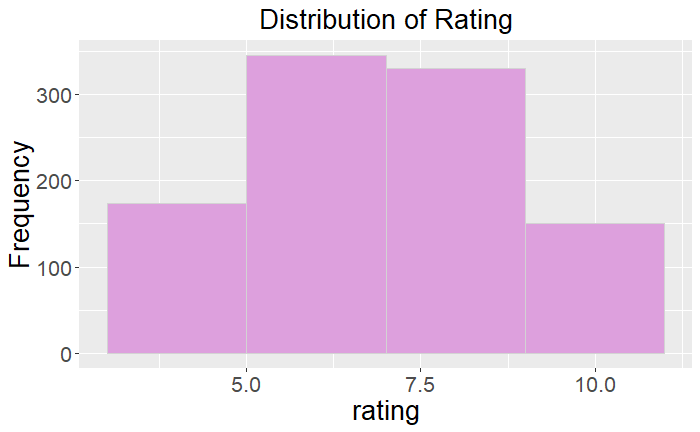

```r
# plot a histogram to visualize the distribution of values in 'rating' column
options(repr.plot.width = 8, repr.plot.height = 6)
p = Sales %>% ggplot(aes(x = rating ))
p + geom_histogram(color="lightgray", fill="plum", binwidth = 2) +
    labs(title = "Distribution of Rating", x = "rating", y = "Frequency") +
    theme(axis.title = element_text(size = 20),
          axis.text = element_text(size=16),
          plot.title = element_text(hjust = 0.5, size = 20))
```

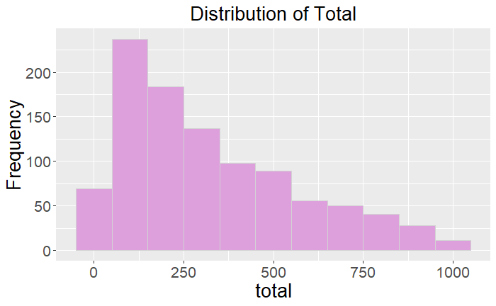

```r
# plot a histogram to visualize the distribution of values in 'total' column
options(repr.plot.width = 8, repr.plot.height = 6)
p = Sales %>% ggplot(aes(x = total ))
p + geom_histogram(color="lightgray", fill="plum", binwidth = 100) +
    labs(title = "Distribution of Total", x = "total", y = "Frequency") +
    theme(axis.title = element_text(size = 20),
          axis.text = element_text(size=16),
          plot.title = element_text(hjust = 0.5, size = 20))
```

###Categorical columns

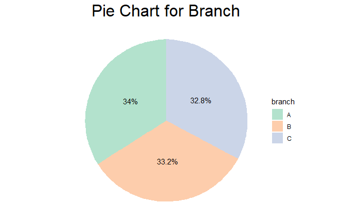

```r
# plot a pie chart to visualize the proportion of values in the 'branch' column
data.branch = Sales %>%
  filter(branch != "NA") %>%
  group_by(branch) %>%
  count() %>%
  ungroup()%>%
  arrange(desc(branch)) %>%
  mutate(percentage = round(n/sum(n),4)*100,
         lab.pos = cumsum(percentage)-.5*percentage)
ggplot(data = data.branch,
       aes(x = "", y = percentage, fill = branch))+
  geom_bar(stat = "identity")+
  coord_polar("y", start = 0) +
  geom_text(aes(y = lab.pos, label = paste(percentage,"%", sep = "")), col = "black") +
  theme_void() + scale_fill_brewer(palette = "Pastel2") + labs(title= 'Pie Chart for Branch') +
  theme(plot.title = element_text(hjust = 0.5, size = 24))
```

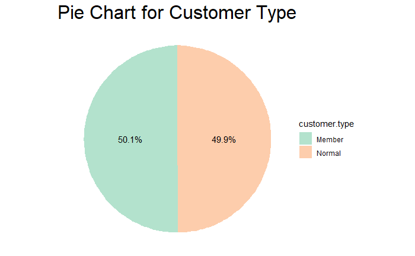

```r
# plot a pie chart to visualize the proportion of values in the 'customer_type' column
data.customer.type = Sales %>%
  filter(customer.type != "NA") %>%
  group_by(customer.type) %>%
  count() %>%
  ungroup()%>%
  arrange(desc(customer.type)) %>%
  mutate(percentage = round(n/sum(n),4)*100,
         lab.pos = cumsum(percentage)-.5*percentage)
ggplot(data = data.customer.type,
       aes(x = "", y = percentage, fill = customer.type))+
  geom_bar(stat = "identity")+
  coord_polar("y", start = 0) +
  geom_text(aes(y = lab.pos, label = paste(percentage,"%", sep = "")), col = "black") +
  theme_void() + scale_fill_brewer(palette = "Pastel2") + labs(title= 'Pie Chart for Customer Type') +
  theme(plot.title = element_text(hjust = 0.5, size = 24))
```